# PHAR 305 Final Project

2026-03-24

# Instructions

## Rename this file

Replace “lastname_firstname” in the file name with your own last and first name before beginning the project (e.g., Doe_Jane_PHAR305_finalproject.Rmd). The same naming convention will automatically apply when you knit this file to HTML.

## Overview

This project will assess your understanding of how to formulate and test a scientific research question, conduct and interpret a regression analysis, and contextualize your research findings. You will apply these concepts to a dataset of your choice.

**Total Points: 60**

Deadline to submit knit HTML and RMD files on Canvas: April 7, 2026 at 11:59 PM

## Requirements

1. **Choose ONE dataset** from the options provided on Canvas
2. Complete ALL sections of this analysis template
3. Show all code and provide written interpretations
4. Knit your final document to HTML before submitting

## Grading Criteria

| Section | Topic | Points |
| --- | --- | --- |
| Part 0 | Dataset Identified | 1 |
| Part 1 | Research Question & Hypotheses | 11 |
| Part 2 | Data Exploration | 13 |
| Part 3 | Regression Analysis | 15 |
| Part 4 | Communicating Results | 6 |
| Part 5 | Limitations & Interpretation | 6 |
| Overall | RMD Rendered Successfully | 3 |
| Overall | Code readability | 5 |
| Total |  | 60 |

# Your Dataset Selection (/1 point)

# Part 1: Research Question & Hypotheses (/11 points)

## 1.1 Load Your Dataset (1 point)

Load your chosen dataset.

```r
# Load the Sleep Health and Lifestyle dataset
# Using read_csv() from the readr package (part of tidyverse)
data <- read_csv("Sleep_health_and_lifestyle_dataset.csv")

# Quick look at the raw data
head(data)
```

```
## # A tibble: 6 × 13
##   `Person ID` Gender   Age Occupation        `Sleep Duration` `Quality of Sleep`
##         <dbl> <chr>  <dbl> <chr>                        <dbl>              <dbl>
## 1           1 Male      27 Software Engineer              6.1                  6
## 2           2 Male      28 Doctor                         6.2                  6
## 3           3 Male      28 Doctor                         6.2                  6
## 4           4 Male      28 Sales Representa…              5.9                  4
## 5           5 Male      28 Sales Representa…              5.9                  4
## 6           6 Male      28 Software Engineer              5.9                  4
## # ℹ 7 more variables: `Physical Activity Level` <dbl>, `Stress Level` <dbl>,
## #   `BMI Category` <chr>, `Blood Pressure` <chr>, `Heart Rate` <dbl>,
## #   `Daily Steps` <dbl>, `Sleep Disorder` <chr>
```

```r
# This step is optional - consider whether you variables are already user friendly
# Rename columns to shorter, informative, code-friendly names with no spaces (which can cause errors)
# Using rename() from the dplyr package (part of tidyverse)
data <- rename(data,
  person_id         = "Person ID",
  sleep_duration    = "Sleep Duration",
  quality_of_sleep  = "Quality of Sleep",
  physical_activity = "Physical Activity Level",
  stress_level      = "Stress Level",
  bmi_category      = "BMI Category",
  blood_pressure    = "Blood Pressure",
  heart_rate        = "Heart Rate",
  daily_steps       = "Daily Steps",
  sleep_disorder    = "Sleep Disorder",
  Sex               = "Gender"
)
```

```r
# This step is optional - consider whether you need to recategorize any variables or set the reference category for categorical variables. If you if you don't specify, R will chose the first category in alphabetical order as the reference.
# Clean and create new variables for analysis

# Clean up BMI: merge "Normal" and "Normal Weight" into one level
data$bmi_category <- trimws(data$bmi_category)
data$bmi_category[data$bmi_category == "Normal"] <- "Normal Weight"

# Set reference categories for factor variables
data$Sex <- relevel(factor(data$Sex), ref = "Female")
data$bmi_category <- relevel(factor(data$bmi_category), ref = "Normal Weight")
data$sleep_disorder <- relevel(factor(data$sleep_disorder), ref = "None")

# Create a binary variable for sleep disorder (for logistic regression)
data$has_disorder <- ifelse(data$sleep_disorder != "None", 1, 0)

# Scale daily steps to thousands (for Poisson regression)
data$steps_thousands <- round(data$daily_steps / 1000)

# Verify the cleaned data
head(data)
```

```
## # A tibble: 6 × 15
##   person_id Sex     Age Occupation           sleep_duration quality_of_sleep
##       <dbl> <fct> <dbl> <chr>                         <dbl>            <dbl>
## 1         1 Male     27 Software Engineer               6.1                6
## 2         2 Male     28 Doctor                          6.2                6
## 3         3 Male     28 Doctor                          6.2                6
## 4         4 Male     28 Sales Representative            5.9                4
## 5         5 Male     28 Sales Representative            5.9                4
## 6         6 Male     28 Software Engineer               5.9                4
## # ℹ 9 more variables: physical_activity <dbl>, stress_level <dbl>,
## #   bmi_category <fct>, blood_pressure <chr>, heart_rate <dbl>,
## #   daily_steps <dbl>, sleep_disorder <fct>, has_disorder <dbl>,
## #   steps_thousands <dbl>
```

## 1.2 Define Your Research Question (8 points)

Based on your chosen dataset, formulate a research question using the PICO framework (5 points):

**Population**

**Intervention**

**Comparator**

**Outcome**

Now, identify the variables **in your dataset** that will allow you to test this research question (3 points):

**Outcome (Y)** *What is your dependent variable?*

**Exposure (X)** *What is your main predictor of interest?*

**List 2-3 potential confounders for the X-Y relationship**

## 1.3 Justify Your Confounders (2 points)

For each confounder you identified, provide a 2-3 sentence conceptual justification based on the definition of a confounder that we learned in class. Include at least one reference to a published study to support your justification for each confounder.

*Tip:* You can cite studies within markdown by including a URL, for example: https://pubmed.ncbi.nlm.nih.gov/

# Part 2: Data Exploration (/13 points)

## 2.1 Summary Statistics (4 points)

Provide at least one informative summary statistic for each of your key variables (outcome, exposure, and each of your confounders identified in Section 1.2).

```r
# Summary statistics for the outcome variable (Quality of Sleep)
summary(data$quality_of_sleep)
```

```
##    Min. 1st Qu.  Median    Mean 3rd Qu.    Max.
##   4.000   6.000   7.000   7.313   8.000   9.000
```

```r
sd(data$quality_of_sleep)
```

```
## [1] 1.196956
```

```r
# Summary statistics for the exposure variable (Physical Activity Level)
summary(data$physical_activity)
```

```
##    Min. 1st Qu.  Median    Mean 3rd Qu.    Max.
##   30.00   45.00   60.00   59.17   75.00   90.00
```

```r
sd(data$physical_activity)
```

```
## [1] 20.8308
```

```r
# Confounder 1: Age (continuous)
summary(data$Age)
```

```
##    Min. 1st Qu.  Median    Mean 3rd Qu.    Max.
##   27.00   35.25   43.00   42.18   50.00   59.00
```

```r
sd(data$Age)
```

```
## [1] 8.673133
```

```r
# Confounder 2: Stress Level (continuous)
summary(data$stress_level)
```

```
##    Min. 1st Qu.  Median    Mean 3rd Qu.    Max.
##   3.000   4.000   5.000   5.385   7.000   8.000
```

```r
sd(data$stress_level)
```

```
## [1] 1.774526
```

```r
# Confounder 3: Sex (categorical — show counts and proportions)
table(data$Sex)
```

```
##
## Female   Male
##    185    189
```

```r
prop.table(table(data$Sex))
```

```
##
##    Female      Male
## 0.4946524 0.5053476
```

## 2.2 Distribution of Outcome Variable (3 points)

Create a visualization showing the distribution of your outcome variable.

**Tip: See lecture notes from Sessions 10/11 for suggestions of appropriate visualizations for categorical variables (e.g. bar chart)**

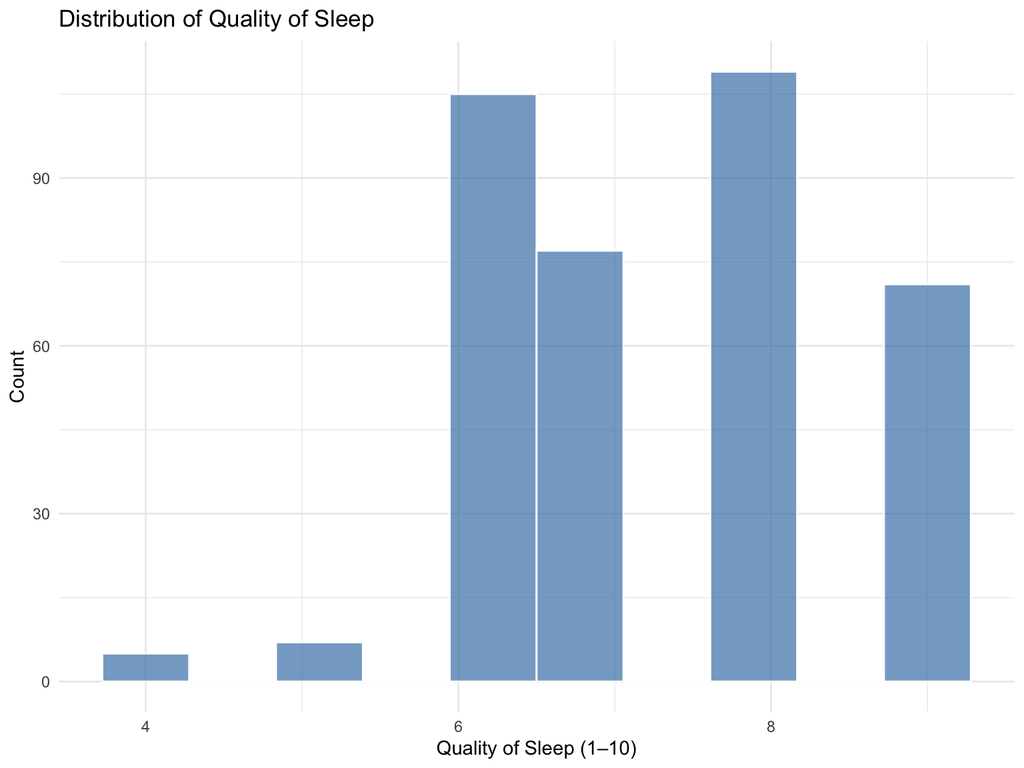

```r
# Histogram of the outcome variable: Quality of Sleep
# Using ggplot() from the ggplot2 package (part of tidyverse)

ggplot(data, aes(x = quality_of_sleep)) +       # set up the plot; aes() maps the variable to the x-axis
  geom_histogram(bins = 10, fill = "steelblue",  # draw histogram bars with 10 bins
                 alpha = 0.7, color = "white") +  # alpha = transparency, color = bar border
  labs(                                           # add labels for the title and axes
    title = "Distribution of Quality of Sleep",
    x = "Quality of Sleep (1–10)",
    y = "Count"
  ) +
  theme_minimal()                                 # apply a clean, minimal theme
```

**Interpretation**

## 2.3 Exposure-Outcome Relationship (3 points)

Create a visualization showing the relationship between your exposure and outcome.

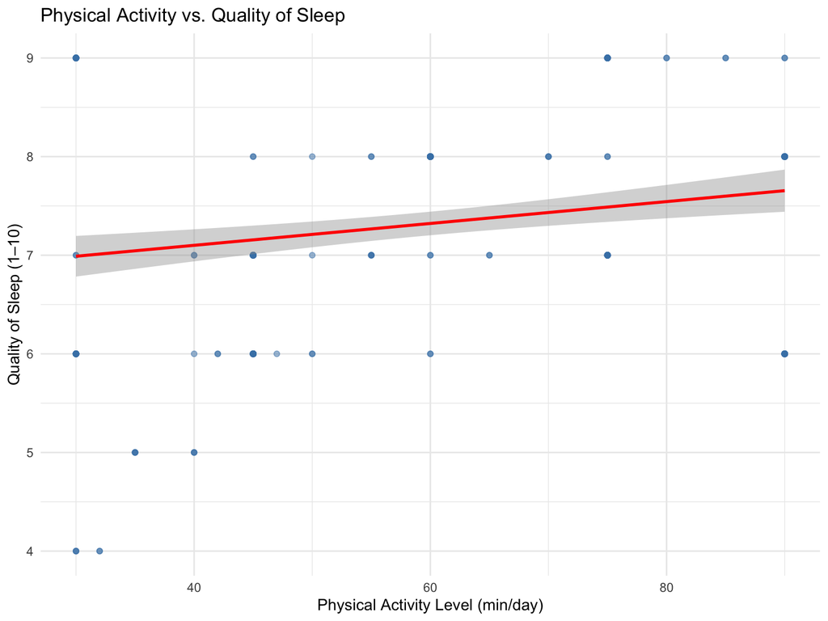

```r
# Scatterplot: Physical Activity (X) vs. Quality of Sleep (Y)
# Using ggplot() from the ggplot2 package (part of tidyverse)

ggplot(data, aes(x = physical_activity, y = quality_of_sleep)) +  # set up plot; map X and Y variables
  geom_point(alpha = 0.5, color = "steelblue") +                  # draw individual data points
  geom_smooth(method = "lm", se = TRUE, color = "red") +          # add a linear trend line with 95% CI shading
  labs(                                                            # add labels for title and axes
    title = "Physical Activity vs. Quality of Sleep",
    x = "Physical Activity Level (min/day)",
    y = "Quality of Sleep (1–10)"
  ) +
  theme_minimal()                                                  # apply a clean, minimal theme
```

**Interpretation**

## 2.4 Exploring Potential Confounding (3 points)

Show evidence that at least one of your confounders is associated with BOTH the exposure and the outcome.

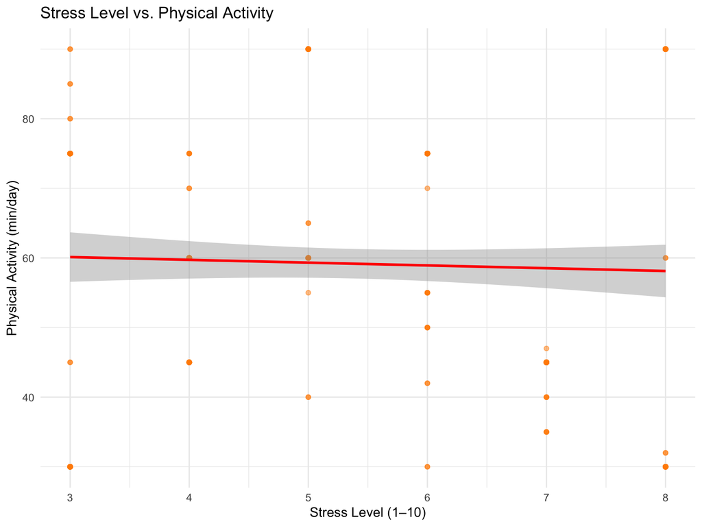

```r
# Plot 1: Confounder (Stress) vs. Exposure (Physical Activity)
# Using ggplot() from the ggplot2 package (part of tidyverse)

ggplot(data, aes(x = stress_level, y = physical_activity)) +  # set up plot; map X and Y variables
  geom_point(alpha = 0.5, color = "darkorange") +              # draw individual data points
  geom_smooth(method = "lm", se = TRUE, color = "red") +      # add a linear trend line with 95% CI shading
  labs(                                                        # add labels for title and axes
    title = "Stress Level vs. Physical Activity",
    x = "Stress Level (1–10)",
    y = "Physical Activity (min/day)"
  ) +
  theme_minimal()                                              # apply a clean, minimal theme
```

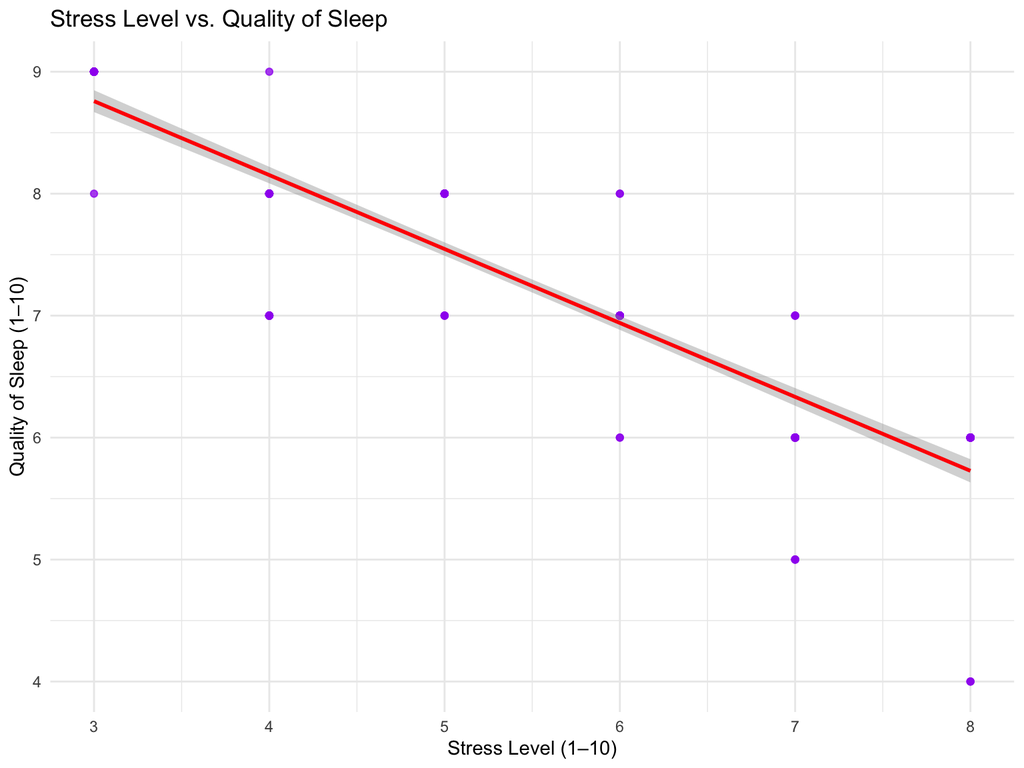

```r
# Plot 2: Confounder (Stress) vs. Outcome (Quality of Sleep)
# Using ggplot() from the ggplot2 package (part of tidyverse)

ggplot(data, aes(x = stress_level, y = quality_of_sleep)) +  # set up plot; map X and Y variables
  geom_point(alpha = 0.5, color = "purple") +                 # draw individual data points
  geom_smooth(method = "lm", se = TRUE, color = "red") +     # add a linear trend line with 95% CI shading
  labs(                                                       # add labels for title and axes
    title = "Stress Level vs. Quality of Sleep",
    x = "Stress Level (1–10)",
    y = "Quality of Sleep (1–10)"
  ) +
  theme_minimal()                                             # apply a clean, minimal theme
```

**Interpretation**

**Tip: Remember that a lack of clear evidence of an association with the exposure/outcome in your visualization or summary table does NOT mean that the variable is not a confounder, only that your particular analysis may not provide strong evidence of a relationship. See Session 4 `Confounding_Summary.pdf`for a reminder of the importance of the conceptual definition over the numeric/visual demonstration of confounding in your dataset, which may be misleading.**

# Part 3: Regression Analysis (/15 points)

## 3.1 Choose the Appropriate Regression Model (2 points)

Based on your outcome variable, select the appropriate regression model:

**a) What type of outcome variable do you have? (1 sentence)**

**b) Which regression model will you use and why? (2-3 sentences)**

## 3.2 Unadjusted (Simple) Regression (4 points)

**Tip: We provide code for linear, logistic and poisson models. Choose only ONE type of model that corresponds with your outcome variable type.**

Fit a simple regression model with only your exposure variable as the predictor. Use the appropriate model type based on your answer above.

```r
# ---- LINEAR REGRESSION (continuous outcome: quality_of_sleep) ----
# Simple model: outcome ~ exposure only

model_simple_linear <- lm(quality_of_sleep ~ physical_activity, data = data)
```

```r
# Using tidy() from the broom package
# tidy() converts model output into a clean data frame with one row per coefficient

tidy_simple_linear <- tidy(model_simple_linear, conf.int = TRUE)
tidy_simple_linear[, sapply(tidy_simple_linear, is.numeric)] <-
  round(tidy_simple_linear[, sapply(tidy_simple_linear, is.numeric)], 3)

print(tidy_simple_linear)
```

```
## # A tibble: 2 × 7
##   term              estimate std.error statistic p.value conf.low conf.high
##   <chr>                <dbl>     <dbl>     <dbl>   <dbl>    <dbl>     <dbl>
## 1 (Intercept)          6.66      0.183     36.3        0    6.30      7.02
## 2 physical_activity    0.011     0.003      3.79       0    0.005     0.017
```

```r
# ---- LOGISTIC REGRESSION (binary outcome: has_disorder) ----
# Simple model: does physical activity predict having a sleep disorder?
model_simple_logistic <- glm(
  has_disorder ~ physical_activity,
  data = data,
  family = binomial
)
```

```r
# Using tidy() from the broom package
# tidy() converts model output into a clean data frame with one row per coefficient
# exponentiate = TRUE transforms log-odds into Odds Ratios (OR)
tidy_simple_logistic <- tidy(model_simple_logistic, conf.int = TRUE, exponentiate = TRUE)
tidy_simple_logistic[, sapply(tidy_simple_logistic, is.numeric)] <-
  round(tidy_simple_logistic[, sapply(tidy_simple_logistic, is.numeric)], 3)

print(tidy_simple_logistic)
```

```
## # A tibble: 2 × 7
##   term              estimate std.error statistic p.value conf.low conf.high
##   <chr>                <dbl>     <dbl>     <dbl>   <dbl>    <dbl>     <dbl>
## 1 (Intercept)          0.472     0.32      -2.35   0.019    0.25      0.879
## 2 physical_activity    1.01      0.005      1.35   0.178    0.997     1.02
```

```r
# ---- POISSON REGRESSION (count outcome: steps_thousands) ----
# Simple model: does physical activity predict daily step count?
model_simple_poisson <- glm(
  steps_thousands ~ physical_activity,
  data = data,
  family = poisson
)
```

```r
# Using tidy() from the broom package
# tidy() converts model output into a clean data frame with one row per coefficient
# exponentiate = TRUE transforms log-counts into Incidence Rate Ratios (IRR)
tidy_simple_poisson <- tidy(model_simple_poisson, conf.int = TRUE, exponentiate = TRUE)
tidy_simple_poisson[, sapply(tidy_simple_poisson, is.numeric)] <-
  round(tidy_simple_poisson[, sapply(tidy_simple_poisson, is.numeric)], 3)

print(tidy_simple_poisson)
```

```
## # A tibble: 2 × 7
##   term              estimate std.error statistic p.value conf.low conf.high
##   <chr>                <dbl>     <dbl>     <dbl>   <dbl>    <dbl>     <dbl>
## 1 (Intercept)           3.99     0.063     21.8        0     3.52      4.51
## 2 physical_activity     1.01     0.001      9.22       0     1.01      1.01
```

**Interpretation of Exposure Effect**

Is this association statistically significant? Interpret the confidence interval AND p-value (1-2 sentences).

## 3.3 Adjusted (Multiple) Regression (4 points)

Fit a multiple regression model adjusting for your confounders selected in Section 1.2. Use the same model type as above.

```r
# ---- ADJUSTED LINEAR REGRESSION ----
# Add confounders: Age, Sex, stress_level
model_adj_linear <- lm(
  quality_of_sleep ~ physical_activity + Age + Sex + stress_level,
  data = data
)
```

```r
# Using tidy() from the broom package
# tidy() converts model output into a clean data frame with one row per coefficient
tidy_adj_linear <- tidy(model_adj_linear, conf.int = TRUE)
tidy_adj_linear[, sapply(tidy_adj_linear, is.numeric)] <-
  round(tidy_adj_linear[, sapply(tidy_adj_linear, is.numeric)], 3)

print(tidy_adj_linear)
```

```
## # A tibble: 5 × 7
##   term              estimate std.error statistic p.value conf.low conf.high
##   <chr>                <dbl>     <dbl>     <dbl>   <dbl>    <dbl>     <dbl>
## 1 (Intercept)          8.88      0.201     44.1        0    8.48      9.28
## 2 physical_activity    0.008     0.001      6.48       0    0.005     0.01
## 3 Age                  0.024     0.004      6.63       0    0.017     0.031
## 4 SexMale              0.388     0.061      6.40       0    0.269     0.507
## 5 stress_level        -0.597     0.015    -39.8        0   -0.627    -0.568
```

```r
# ---- ADJUSTED LOGISTIC REGRESSION ----
# Add confounders to the logistic model
model_adj_logistic <- glm(
  has_disorder ~ physical_activity + Age + Sex + stress_level,
  data = data,
  family = binomial
)
```

```r
# Using tidy() from the broom package
# tidy() converts model output into a clean data frame with one row per coefficient
# exponentiate = TRUE transforms log-odds into Odds Ratios (OR)
tidy_adj_logistic <- tidy(model_adj_logistic, conf.int = TRUE, exponentiate = TRUE)
tidy_adj_logistic[, sapply(tidy_adj_logistic, is.numeric)] <-
  round(tidy_adj_logistic[, sapply(tidy_adj_logistic, is.numeric)], 3)

print(tidy_adj_logistic)
```

```
## # A tibble: 5 × 7
##   term              estimate std.error statistic p.value conf.low conf.high
##   <chr>                <dbl>     <dbl>     <dbl>   <dbl>    <dbl>     <dbl>
## 1 (Intercept)          0         1.71      -8.05    0       0         0
## 2 physical_activity    1.01      0.008      1.41    0.16    0.996     1.03
## 3 Age                  1.21      0.024      7.99    0       1.16      1.27
## 4 SexMale              0.201     0.448     -3.58    0       0.08      0.469
## 5 stress_level         2.86      0.157      6.72    0       2.15      3.98
```

```r
# ---- ADJUSTED POISSON REGRESSION ----
# Add confounders to the Poisson model
model_adj_poisson <- glm(
  steps_thousands ~ physical_activity + Age + Sex + stress_level,
  data = data,
  family = poisson
)
```

```r
# Using tidy() from the broom package
# tidy() converts model output into a clean data frame with one row per coefficient
# exponentiate = TRUE transforms log-counts into Incidence Rate Ratios (IRR)
tidy_adj_poisson <- tidy(model_adj_poisson, conf.int = TRUE, exponentiate = TRUE)
tidy_adj_poisson[, sapply(tidy_adj_poisson, is.numeric)] <-
  round(tidy_adj_poisson[, sapply(tidy_adj_poisson, is.numeric)], 3)

print(tidy_adj_poisson)
```

```
## # A tibble: 5 × 7
##   term              estimate std.error statistic p.value conf.low conf.high
##   <chr>                <dbl>     <dbl>     <dbl>   <dbl>    <dbl>     <dbl>
## 1 (Intercept)          4.01      0.165      8.4    0        2.90       5.54
## 2 physical_activity    1.01      0.001      9.13   0        1.01       1.01
## 3 Age                  0.997     0.003     -1.01   0.314    0.991      1.00
## 4 SexMale              0.938     0.05      -1.29   0.198    0.85       1.03
## 5 stress_level         1.03      0.012      2.18   0.029    1.00       1.05
```

**Interpretation of Exposure Effect after adjusting for confounders**

Identify and interpret the appropriate coefficient in the context of your research question (2-3 sentences).

Is this association statistically significant? Interpret the confidence interval AND p-value (1-2 sentences).

## 3.4 Compare Unadjusted vs. Adjusted Estimates (5 points)

Create a numeric AND visual comparison of your unadjusted and adjusted estimates for the exposure variable.

```r
# Extract the physical_activity coefficient from unadjusted vs adjusted linear models

unadj_lin <- subset(tidy_simple_linear, term == "physical_activity")
unadj_lin$Model <- "Linear – Unadjusted"

adj_lin <- subset(tidy_adj_linear, term == "physical_activity")
adj_lin$Model <- "Linear – Adjusted"

compare_linear <- rbind(unadj_lin, adj_lin)
print(compare_linear)
```

```
## # A tibble: 2 × 8
##   term             estimate std.error statistic p.value conf.low conf.high Model
##   <chr>               <dbl>     <dbl>     <dbl>   <dbl>    <dbl>     <dbl> <chr>
## 1 physical_activi…    0.011     0.003      3.79       0    0.005     0.017 Line…
## 2 physical_activi…    0.008     0.001      6.48       0    0.005     0.01  Line…
```

```r
# Extract the physical_activity coefficient from unadjusted vs adjusted logistic models

unadj_log <- subset(tidy_simple_logistic, term == "physical_activity")
unadj_log$Model <- "Logistic – Unadjusted"

adj_log <- subset(tidy_adj_logistic, term == "physical_activity")
adj_log$Model <- "Logistic – Adjusted"

compare_logistic <- rbind(unadj_log, adj_log)
print(compare_logistic)
```

```
## # A tibble: 2 × 8
##   term             estimate std.error statistic p.value conf.low conf.high Model
##   <chr>               <dbl>     <dbl>     <dbl>   <dbl>    <dbl>     <dbl> <chr>
## 1 physical_activi…     1.01     0.005      1.35   0.178    0.997      1.02 Logi…
## 2 physical_activi…     1.01     0.008      1.41   0.16     0.996      1.03 Logi…
```

```r
# Extract the physical_activity coefficient from unadjusted vs adjusted Poisson models

unadj_pois <- subset(tidy_simple_poisson, term == "physical_activity")
unadj_pois$Model <- "Poisson – Unadjusted"

adj_pois <- subset(tidy_adj_poisson, term == "physical_activity")
adj_pois$Model <- "Poisson – Adjusted"

compare_poisson <- rbind(unadj_pois, adj_pois)
print(compare_poisson)
```

```
## # A tibble: 2 × 8
##   term             estimate std.error statistic p.value conf.low conf.high Model
##   <chr>               <dbl>     <dbl>     <dbl>   <dbl>    <dbl>     <dbl> <chr>
## 1 physical_activi…     1.01     0.001      9.22       0     1.01      1.01 Pois…
## 2 physical_activi…     1.01     0.001      9.13       0     1.01      1.01 Pois…
```

```r
# Combine all into one comparison table

comparison_table <- rbind(compare_linear, compare_logistic, compare_poisson)
comparison_table <- comparison_table[, c("Model", "estimate", "conf.low", "conf.high", "p.value")]

print(comparison_table)
```

```
## # A tibble: 6 × 5
##   Model                 estimate conf.low conf.high p.value
##   <chr>                    <dbl>    <dbl>     <dbl>   <dbl>
## 1 Linear – Unadjusted      0.011    0.005     0.017   0
## 2 Linear – Adjusted        0.008    0.005     0.01    0
## 3 Logistic – Unadjusted    1.01     0.997     1.02    0.178
## 4 Logistic – Adjusted      1.01     0.996     1.03    0.16
## 5 Poisson – Unadjusted     1.01     1.01      1.01    0
## 6 Poisson – Adjusted       1.01     1.01      1.01    0
```

```r
# Add columns for faceting and labelling the forest plot

comparison_table$Family <- ifelse(grepl("Linear", comparison_table$Model), "Linear (Coefficient)",
                           ifelse(grepl("Logistic", comparison_table$Model), "Logistic (Odds Ratio)",
                                  "Poisson (IRR)"))

comparison_table$Type <- ifelse(grepl("Unadjusted", comparison_table$Model), "Unadjusted", "Adjusted")
```

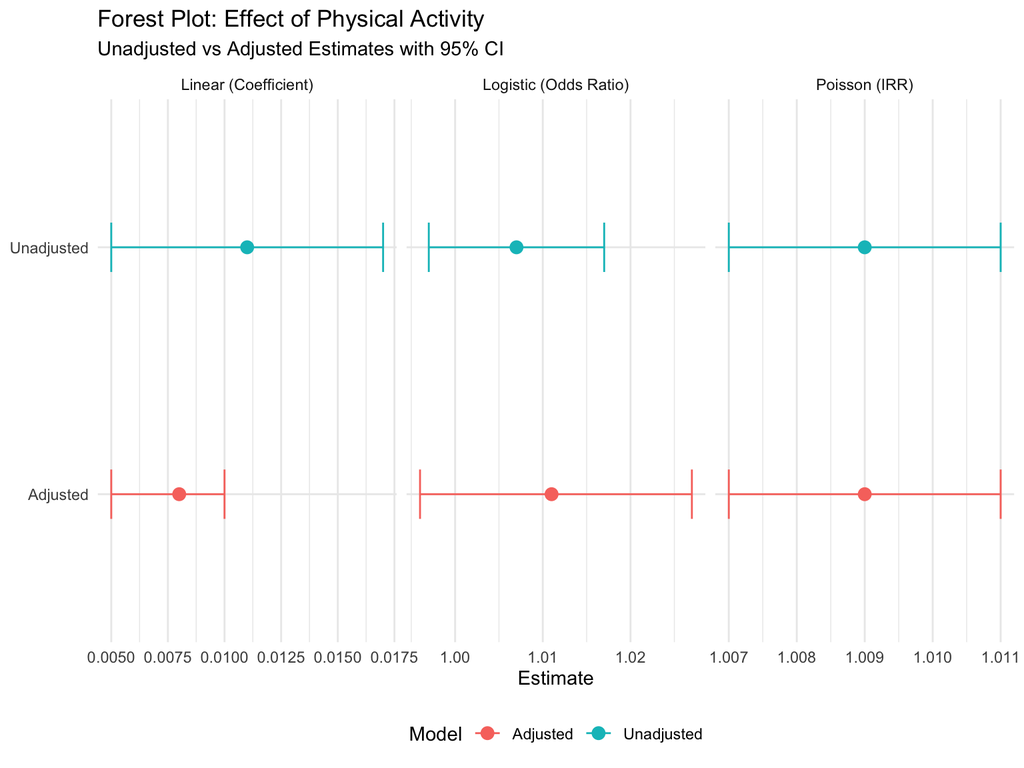

```r
# Forest plot: Unadjusted vs Adjusted estimates with 95% CI
# Using ggplot() from the ggplot2 package (part of tidyverse)
ggplot(comparison_table, aes(x = estimate, y = Type, colour = Type)) +  # set up plot; map estimate to x, model type to y
  geom_point(size = 3) +                                                 # draw point estimates
  geom_errorbar(aes(xmin = conf.low, xmax = conf.high), height = 0.2) + # draw horizontal 95% CI bars
  facet_wrap(~ Family, scales = "free_x") +                              # create separate panels for each regression type
  labs(                                                                   # add labels for title and axes
    title = "Forest Plot: Effect of Physical Activity",
    subtitle = "Unadjusted vs Adjusted Estimates with 95% CI",
    x = "Estimate",
    y = NULL,
    colour = "Model"
  ) +
  theme_minimal() +                                                      # apply a clean, minimal theme
  theme(legend.position = "bottom")                                      # move legend to the bottom
```

**Analysis of Confounding**

# Part 4: Communicating Results (/6 points)

## 4.1 Publication-Ready Table (2 points)

Create a professional results table for your adjusted regression model.

```r
# Format the adjusted linear model results for a journal-style table

pub_table <- tidy_adj_linear

# Create readable variable names
pub_table$Variable <- pub_table$term
pub_table$Variable[pub_table$term == "(Intercept)"]       <- "Intercept"
pub_table$Variable[pub_table$term == "physical_activity"] <- "Physical Activity Level"
pub_table$Variable[pub_table$term == "Age"]               <- "Age (years)"
pub_table$Variable[pub_table$term == "SexMale"]           <- "Sex (Male vs Female)"
pub_table$Variable[pub_table$term == "stress_level"]      <- "Stress Level"

# Paste confidence interval into one column
pub_table$CI <- paste0("(", pub_table$conf.low, ", ", pub_table$conf.high, ")")

# Format p-value
pub_table$P_value <- ifelse(pub_table$p.value < 0.001, "< 0.001", round(pub_table$p.value, 3))

# Keep only the columns we need
pub_table <- pub_table[, c("Variable", "estimate", "CI", "P_value")]
colnames(pub_table) <- c("Variable", "Estimate", "95% CI", "P-value")
```

```r
# Display as a nicely formatted table
# Using kable() from the knitr package

kable(pub_table, caption = "Table 1. Adjusted Linear Regression Results – Predictors of Sleep Quality")
```

Table 1. Adjusted Linear Regression Results – Predictors of Sleep Quality

| Variable | Estimate | 95% CI | P-value |
| --- | --- | --- | --- |
| Intercept | 8.879 | (8.483, 9.275) | < 0.001 |
| Physical Activity Level | 0.008 | (0.005, 0.01) | < 0.001 |
| Age (years) | 0.024 | (0.017, 0.031) | < 0.001 |
| Sex (Male vs Female) | 0.388 | (0.269, 0.507) | < 0.001 |
| Stress Level | -0.597 | (-0.627, -0.568) | < 0.001 |

## 4.2 Written Results Statement (4 points)

Write a 5-7 sentence results paragraph suitable for a research paper. Your statement should include:

- The research question addressed
- The adjusted effect estimate with units
- The 95% confidence interval
- Whether the effect is statistically significant
- The confounders that were controlled for and how they impacted the effect estimate

# Part 5: Limitations & Interpretation (/6 points)

## 5.1 Limitations (3 points)

Discuss THREE limitations of your dataset or analysis. These could include unmeasured confounding variables, measurement bias in data collection, selection bias in study design, lack of external validity, limitations in the statistical analysis, etc.

**Limitation 1**

Describe and explain the potential impact on results in 2-3 sentences.

**Limitation 2**

Describe and explain the potential impact on results in 2-3 sentences.

**Limitation 3**

Describe and explain the potential impact on results in 2-3 sentences.

## 5.2 Interpretation (3 points)

What is your conclusion on whether your exposure causes the outcome? Provide an informative answer based on your response to Sections 4.2 and 5.1; do not simply state that correlation does not equal causation. Incorporate your assessment of the strengths and weaknesses of your dataset and/or analysis. Answer in 4-5 sentences.

# Submission Checklist

Before submitting, verify that you have the following, successfully rendered in HTML format:

- Selected and loaded ONE dataset
- Stated a clear research question with PICO, X, Y, and confounders
- Justified why your confounders could affect both X and Y
- Created summary statistics and visualizations
- Fit an unadjusted (simple) regression model
- Fit an adjusted (multiple) regression model
- Compared unadjusted vs. adjusted estimates
- Created a publication-ready table
- Written a results statement
- Discussed limitations and interpretation
- Replaced “Your Name Here” with your actual name
- Successfully knitted the document to HTML